# RLAB Transformations Notes

Last Updated: September 23, 2024 08:59:20

## Doctors and Hospitals Example

Use the Doctors and Hospitals example to illustrate using R to get the panoply of residual plots we use for regression diagnostics.

### Load the file

```r
MetroHealth83 <- read.csv(file = "../data/MetroHealth83.csv")
```

### Get the data and extract the 3 variables used in 1.4 notes

- Column 1 is City
- Column 2 is NumMDs
- Column 4 is NumHospitals

```r
MetroHealth83 <- MetroHealth83[, c(1, 2, 4)]
attach(MetroHealth83)
```

The par function helps us control a wide variety of graphical parameters, such as line style, plotting character, axes, color, and on and on.

The command `par(mfrow = c(2,2))` partitions our graphics window into a 2-by-2 panel of panels, so we can get 4 graphs on a single window.

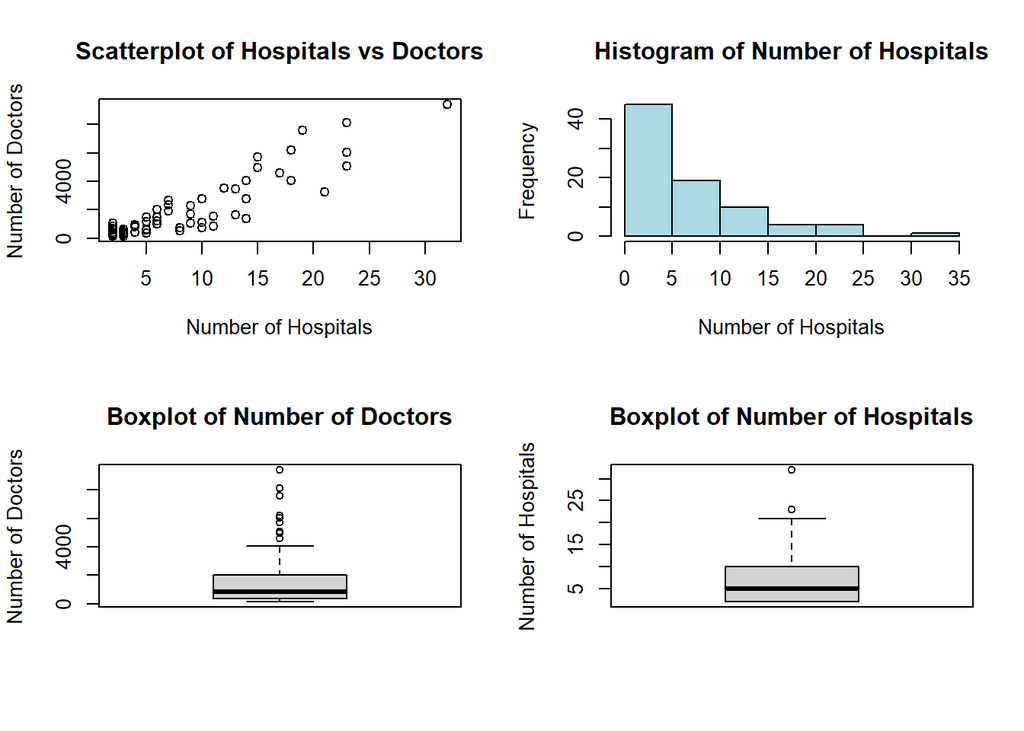

```r
par(mfrow = c(2, 2))

plot(NumHospitals, NumMDs, main = "Scatterplot of Hospitals vs Doctors", xlab = "Number of Hospitals", ylab = "Number of Doctors")

# Histogram of Number of Hospitals
hist(NumHospitals, main = "Histogram of Number of Hospitals", xlab = "Number of Hospitals", ylab = "Frequency", col = "lightblue")

# Boxplot of Number of Doctors
boxplot(NumMDs, main = "Boxplot of Number of Doctors", ylab = "Number of Doctors")

# Boxplot of Number of Hospitals
boxplot(NumHospitals, main = "Boxplot of Number of Hospitals", ylab = "Number of Hospitals")
```

### Fit model

```r
MetroHealth.lm1 <- lm(NumMDs ~ NumHospitals)
```

### Add line to scatterplot

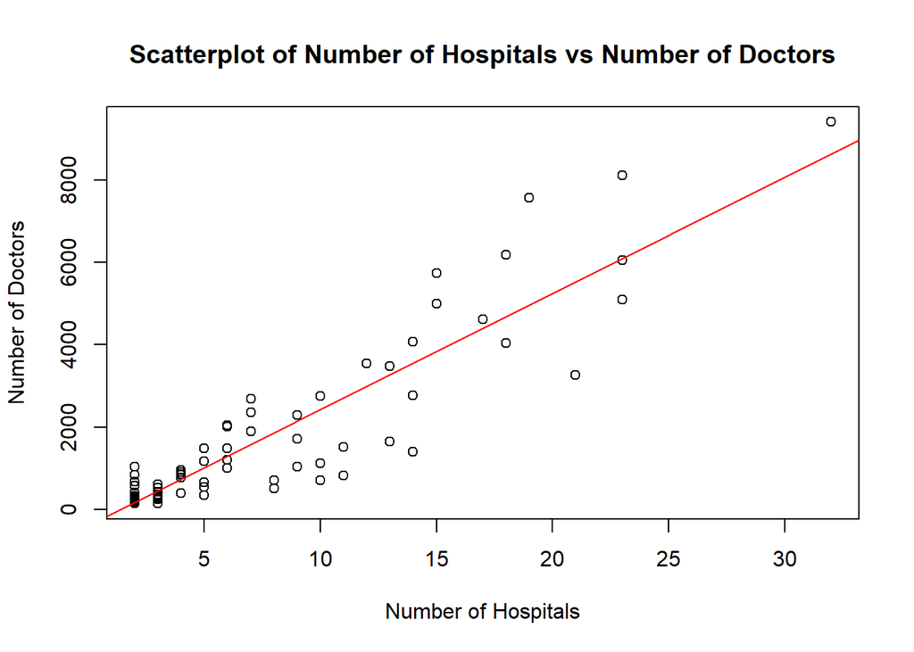

```r
plot(NumHospitals, NumMDs, main = "Scatterplot of Number of Hospitals vs Number of Doctors", xlab = "Number of Hospitals", ylab = "Number of Doctors")
abline(MetroHealth.lm1, col = "red")
```

### Look at scatterplot of residuals

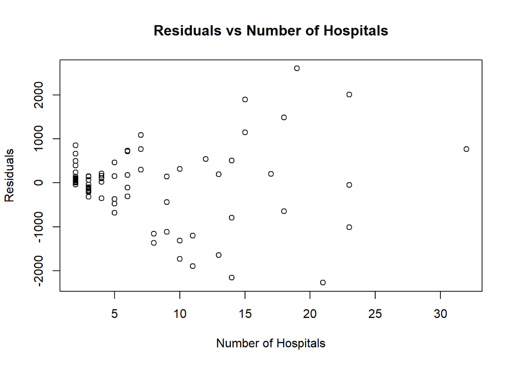

```r
plot(NumHospitals, residuals(MetroHealth.lm1), main = "Residuals vs Number of Hospitals", xlab = "Number of Hospitals", ylab = "Residuals")
```

### Look at distribution of residuals

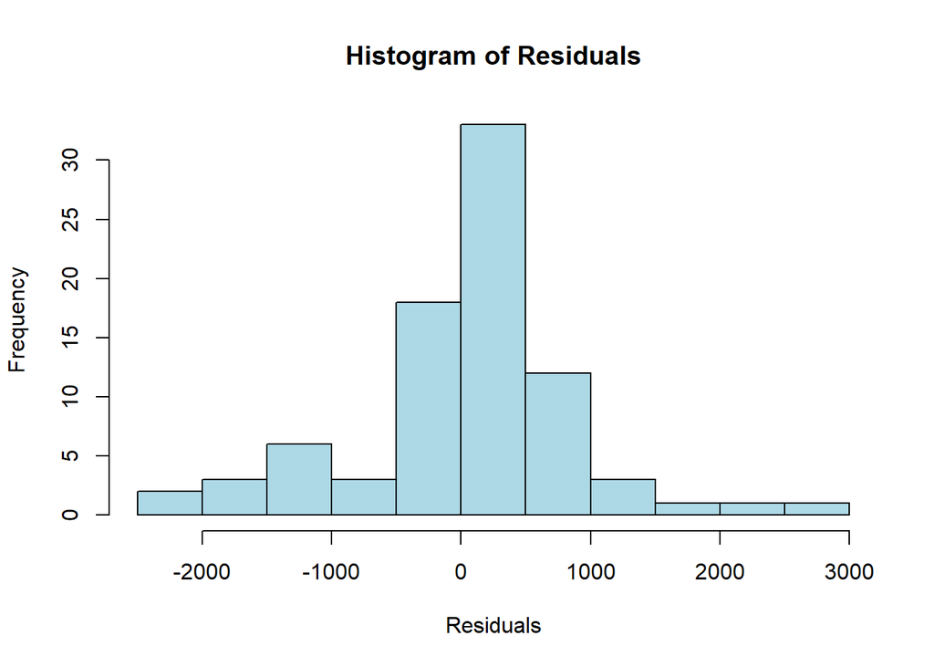

```r
hist(residuals(MetroHealth.lm1), main = "Histogram of Residuals", xlab = "Residuals", ylab = "Frequency", col = "lightblue")
```

### Assess the distribution of residuals

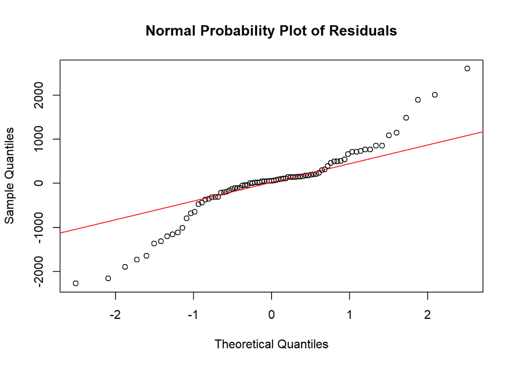

```r
qqnorm(residuals(MetroHealth.lm1), main = "Normal Probability Plot of Residuals")
qqline(residuals(MetroHealth.lm1), col = "red")
```

### Return to single graph window

```r
par(mfrow = c(1, 1))
```

## The R code below fits the square-root model and produces the diagnostic plots.

### Create the square-rooted variable

```r
MetroHealth83$SqrtMDs <- sqrt(MetroHealth83$NumMDs)
```

### Add it to the data frame

```r
MetroHealth83 <- MetroHealth83[, c(1, 2, 3, 4)]
attach(MetroHealth83)
```

### Check that it got added

```r
head(MetroHealth83)
```

```
##                            City NumMDs NumHospitals  SqrtMDs
## 1       Holland-Grand Haven, MI    349            3 18.68154
## 2             Louisville, KY-IN   4042           18 63.57673
## 3              Battle Creek, MI    256            3 16.00000
## 4                   Madison, WI   2679            7 51.75906
## 5             Fort Smith, AR-OK    502            8 22.40536
## 6 Sarasota-Bradenton-Venice, FL   2352            7 48.49742
```

### Check column names

```r
colnames(MetroHealth83)
```

```
## [1] "City"         "NumMDs"       "NumHospitals" "SqrtMDs"
```

## Predicting a Value

The R Code below uses the predict function to predict a value of number of doctors given a value of the number of hospitals

```r
new.data <- data.frame(NumHospitals = c(18, 6))
predict(MetroHealth.lm1, new.data)
```

```
##        1        2
## 4691.063 1306.953
```

The first argument of the function is the model to base the prediction on the predict function is generic, in that it will react appropriately depending on the class of the model object given tbat our model object is a “linear model” object, i.e. one created by the lm function and predict knows what to do with such an object.

The second argument is a data frame giving values of the the explanatory variable(s) that we want to predict response values at.

Multiple values are possible, as the second line of R code illustrates.

The first line defines a data frame called new.data that contains values of the explanatory variable at which we want to predict response values using the model MetroHealth.lm1.

An example in the text used a value of 18 (a hypothetical) for the number of hospitals.

We have added a second hypothetical value of 6, just to illustrate that multiple values are possible.

This new data frame becomes the second argument in the second line of code. This line tells the predict function to use the model MetroHealth.lm1 and make two predictions.

```r
MetroHealth.lm2 <- lm(SqrtMDs ~ NumHospitals)
new.data <- data.frame(NumHospitals = c(18, 6))
predict(MetroHealth.lm2, new.data)^2
```

```
##         1         2
## 4422.2007  993.6232
```

The third line of code asks to predict at the same values of 18 and 6, this time using the model MetroHealth.lm2. Since this model was for the square-rooted data, we must square the results to get back to the predicted number of doctors.

In both cases, the predictions are less than the predictions when using the simple linear model on the untransformed data.

### Define the data frame to predict at.

```r
new.data <- data.frame(NumHospitals = seq(2, 32, by = 0.3))
```

### Adding the Fitted Quadratics — Using R to Draw Curves

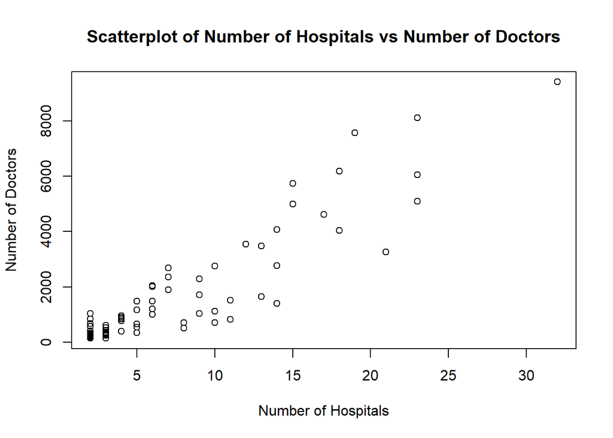

```r
plot(NumHospitals, NumMDs, main = "Scatterplot of Number of Hospitals vs Number of Doctors", xlab = "Number of Hospitals", ylab = "Number of Doctors")
xx <- seq(2, 32, by = 0.3)
yy <- (MetroHealth.lm2$coefficients[1] + MetroHealth.lm2$coefficients[2] * xx + MetroHealth.lm2$coefficients[3] * xx^2)^2
points(xx, yy, type = "l")
```

We conclude this section on diagnostics by showing how R can create the scatterplot in the original scale with the fitted quadratic superimposed.

This code suggests a general approach to fitting or drawing curves, which we illustrate with a second example.

Note the main argument in the plot function, which puts a title on the plot.

### Use the values from the MetroHealth.lm2 list to define your yy function

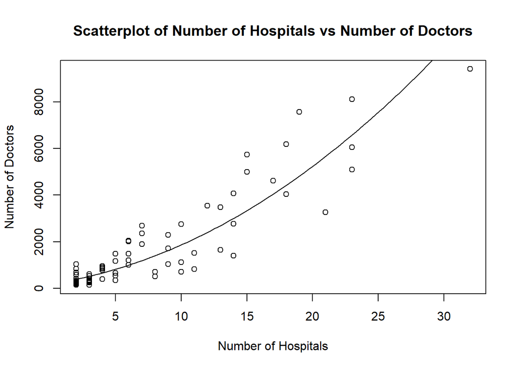

```r
plot(NumHospitals, NumMDs, main = "Scatterplot of Number of Hospitals vs Number of Doctors", xlab = "Number of Hospitals", ylab = "Number of Doctors")
xx <- seq(2, 32, by = 0.3)
yy <- (MetroHealth.lm2$coefficients[1] + MetroHealth.lm2$coefficients[2] * xx)^2
points(xx, yy, type = "l")
```

### Explanation of code

First line reproduces the scatterplot.

The second and third lines of R code ask for the minimum and maximum values of the x-variable, NumHospitals, which we see to be 2 to 32.

Then, we set up a new variable that is a sequence of numbers of length 101, running from 2 to 32.

We did not print xx, but it equals (2, 2.3, 2.6, 2.9, …, 31.7, 32).

Then, we define the variable yy by the quadratic function that untransforms the line we fit to the square-root-transformed data.

Finally, the last line of R code uses the points function.

The points function adds the 101 (xx,yy) points to the plot BUT using the dictates of that third argument type = `l`.

Without that argument we would have seen 101 new open-circle points added to the scatterplot, but the argument is asking to replace the individual points with a broken line connecting these points.

The value of the type argument here is a lower case, not an upper case, L, and not the numeral 1.

There is nothing magical about 101 in this example, you just want to pick enough points so the curve looks like a smooth curve and not the succession of line segments, which in reality it is.

### Separate Example: A mathematical function

We can also graph a mathematical function by itself, not fitted to a scatterplot.

Here is an example of code to graph the function `y = x^2 + x - 1` on the domain `x = [-2, 2]`.

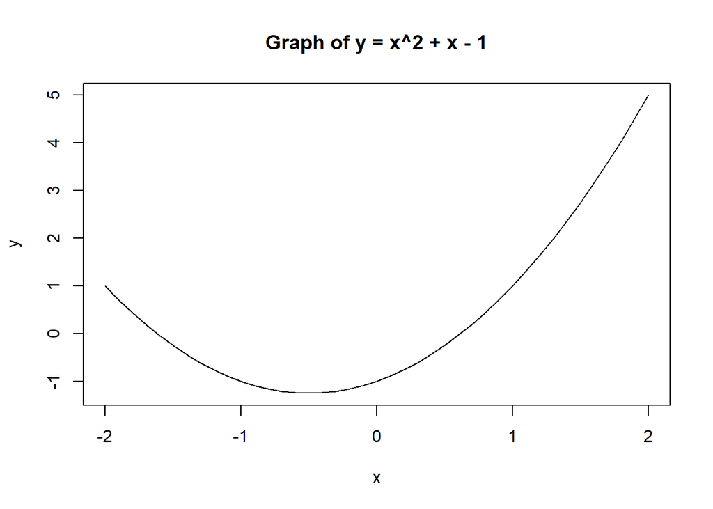

```r
x <- seq(-2, 2, by = 0.1)
y <- x^2 + x - 1
plot(x, y, type = "l", main = "Graph of y = x^2 + x - 1", xlab = "x", ylab = "y")
```